# maxEE22 Cutadapt–ITSxpress ASV alignment 및 계통수

Exact internal-containment와 대표 ASV maximum-likelihood tree

2026-10-15

# 1 1. 분석 목적과 해석 범위

- QC20, maxEE 2/2의 Cutadapt와 ITSxpress 결과만 비교함.
- 동일한 ASV ID가 아니라 **염기서열 자체**를 비교함.
- ITSxpress ASV가 더 긴 Cutadapt ASV 안에 100 bp 이상 exact substring으로 존재하는 관계를 전체 자료에서 확인함.
- 전체 740쌍을 한 tree에 그리면 tip이 겹쳐 판독이 불가능하므로, 전체 포함 관계는 수치로 보존하고 tree는 abundance와 taxonomy 다양성을 반영한 대표 24쌍으로 작성함.
- ITS2는 길이 변이가 크고 대표 tree에는 full sequence와 internal fragment가 함께 있으므로, 이 tree는 species phylogeny 확정용이 아니라 **두 방법의 서열 대응을 시각적으로 점검하는 보조 자료**임.

```r
asv_metrics <- read_csv(
  "Results/01_Preprocessing/05a_unresolved_taxa_ASV_metrics.csv",
  show_col_types = FALSE
)
best_pairs <- read_csv(
  "Results/01_Preprocessing/05n_best_exact_containment_pairs.csv",
  show_col_types = FALSE
)

sequence_info <- asv_metrics |>
  transmute(
    Method, FeatureID, Sequence,
    Length_bp = as.integer(Length_bp),
    Raw_Taxonomy,
    Taxon_Label = deepest_taxon(Raw_Taxonomy),
    ASV_Total_Reads = Total_Reads
  )

cut_info <- sequence_info |>
  filter(Method == "Cutadapt") |>
  rename(
    Cutadapt_FeatureID = FeatureID,
    Cutadapt_Sequence = Sequence,
    Cutadapt_Taxon = Taxon_Label,
    Cutadapt_Raw_Taxonomy = Raw_Taxonomy
  ) |>
  select(Cutadapt_FeatureID, Cutadapt_Sequence, Cutadapt_Taxon,
         Cutadapt_Raw_Taxonomy)

its_info <- sequence_info |>
  filter(Method == "ITSxpress") |>
  rename(
    ITSxpress_FeatureID = FeatureID,
    ITSxpress_Sequence = Sequence,
    ITSxpress_Taxon = Taxon_Label,
    ITSxpress_Raw_Taxonomy = Raw_Taxonomy
  ) |>
  select(ITSxpress_FeatureID, ITSxpress_Sequence, ITSxpress_Taxon,
         ITSxpress_Raw_Taxonomy)

pairs <- best_pairs |>
  left_join(cut_info, by = "Cutadapt_FeatureID") |>
  left_join(its_info, by = "ITSxpress_FeatureID") |>
  mutate(
    ITS_Start = str_locate(Cutadapt_Sequence, fixed(ITSxpress_Sequence))[, "start"],
    ITS_End = ITS_Start + ITSxpress_Length - 1L,
    Left_Flank_bp = ITS_Start - 1L,
    Right_Flank_bp = Cutadapt_Length - ITS_End,
    Total_Flank_bp = Left_Flank_bp + Right_Flank_bp,
    ITS_Fraction = ITSxpress_Length / Cutadapt_Length,
    Taxon_Label = coalesce(ITSxpress_Taxon, Cutadapt_Taxon, "Unassigned")
  )

stopifnot(all(!is.na(pairs$ITS_Start)))
```

# 2 2. 전체 exact-containment 결과

```r
all_summary <- tibble(
  Metric = c(
    "Cutadapt fungal ASVs",
    "ITSxpress fungal ASVs",
    "ITSxpress ASVs with exact containment",
    "Matched ITSxpress ASV fraction",
    "Matched ITSxpress read fraction",
    "Median ITSxpress/Cutadapt length fraction",
    "Median external flank length (bp)"
  ),
  Value = c(
    sum(asv_metrics$Method == "Cutadapt"),
    sum(asv_metrics$Method == "ITSxpress"),
    n_distinct(pairs$ITSxpress_FeatureID),
    n_distinct(pairs$ITSxpress_FeatureID) / sum(asv_metrics$Method == "ITSxpress"),
    sum(pairs$ITSxpress_Total_Reads) /
      sum(asv_metrics$Total_Reads[asv_metrics$Method == "ITSxpress"]),
    median(pairs$ITS_Fraction),
    median(pairs$Total_Flank_bp)
  )
)

datatable_basic(all_summary, 10) |>
  DT::formatSignif("Value", 5)
```

| Metric | Value |
| --- | --- |
| Cutadapt fungal ASVs | 1301 |
| ITSxpress fungal ASVs | 1215 |
| ITSxpress ASVs with exact containment | 740 |
| Matched ITSxpress ASV fraction | 0.6090534979423868 |
| Matched ITSxpress read fraction | 0.9526787944772351 |
| Median ITSxpress/Cutadapt length fraction | 0.5687393183874535 |
| Median external flank length (bp) | 148 |

```r
write_csv(all_summary, file.path(results_dir, "01_exact_containment_summary.csv"))
write_csv(pairs, file.path(results_dir, "02_all_best_exact_containment_pairs.csv"))
```

# 3 3. 대표 pair 선정

각 taxonomy label에서 ITSxpress read 수가 높은 pair를 최대 3개 선택한 뒤, 그중 전체 abundance 상위 24쌍을 사용함. 동일 Cutadapt ASV가 두 번 선택되지 않도록 제한함.

```r
representative_pairs <- pairs |>
  arrange(desc(ITSxpress_Total_Reads), desc(Cutadapt_Total_Reads)) |>
  distinct(Cutadapt_FeatureID, .keep_all = TRUE) |>
  group_by(Taxon_Label) |>
  slice_head(n = 3) |>
  ungroup() |>
  slice_max(ITSxpress_Total_Reads, n = 24, with_ties = FALSE) |>
  arrange(desc(ITSxpress_Total_Reads)) |>
  mutate(Pair_ID = sprintf("P%02d", row_number()))

datatable_basic(
  representative_pairs |>
    transmute(
      Pair_ID, Taxon_Label,
      Cutadapt_Length, ITSxpress_Length,
      Left_Flank_bp, Right_Flank_bp,
      ITS_fraction_percent = 100 * ITS_Fraction,
      Cutadapt_Total_Reads, ITSxpress_Total_Reads
    ),
  24
) |>
  DT::formatRound("ITS_fraction_percent", 1)
```

| Pair_ID | Taxon_Label | Cutadapt_Length | ITSxpress_Length | Left_Flank_bp | Right_Flank_bp | ITS_fraction_percent | Cutadapt_Total_Reads | ITSxpress_Total_Reads |
| --- | --- | --- | --- | --- | --- | --- | --- | --- |
| P01 | Malassezia restricta | 422 | 274 | 108 | 40 | 64.92890995260665 | 124857 | 128880 |
| P02 | Cutaneotrichosporon debeurmannianum | 313 | 165 | 108 | 40 | 52.71565495207668 | 50483 | 57752 |
| P03 | Rhodotorula mucilaginosa | 364 | 218 | 107 | 39 | 59.89010989010989 | 24103 | 24420 |
| P04 | Malassezia restricta | 422 | 274 | 108 | 40 | 64.92890995260665 | 19360 | 19968 |
| P05 | Fungi sp | 302 | 154 | 108 | 40 | 50.99337748344372 | 25439 | 19764 |
| P06 | Didymellaceae | 302 | 154 | 108 | 40 | 50.99337748344372 | 3965 | 16218 |
| P07 | Nigrospora sp | 301 | 153 | 108 | 40 | 50.83056478405316 | 12191 | 14746 |
| P08 | Cladosporium | 296 | 148 | 108 | 40 | 50 | 7822 | 12256 |
| P09 | Alternaria | 306 | 158 | 108 | 40 | 51.63398692810458 | 6245 | 11530 |
| P10 | Malassezia globosa | 426 | 278 | 108 | 40 | 65.25821596244131 | 9388 | 9921 |

[output cut: 14 more lines]

```r
write_csv(representative_pairs,
          file.path(results_dir, "03_representative_containment_pairs.csv"))
```

# 4 4. Cutadapt 내부에서 ITSxpress 서열의 실제 위치

회색 막대는 Cutadapt ASV 전체, 주황색 막대는 그 안에서 **완전히 동일하게 일치하는 ITSxpress 서열 구간**임.

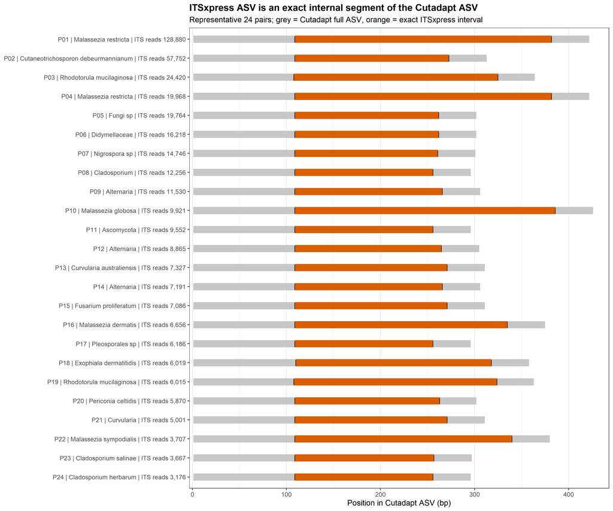

```r
position_data <- representative_pairs |>
  mutate(
    Pair_Label = paste0(Pair_ID, " | ", Taxon_Label,
                        " | ITS reads ", comma(ITSxpress_Total_Reads)),
    Pair_Label = factor(Pair_Label, levels = rev(Pair_Label))
  )

containment_plot <- ggplot(position_data, aes(y = Pair_Label)) +
  geom_segment(aes(x = 1, xend = Cutadapt_Length, yend = Pair_Label),
               linewidth = 4.8, colour = "grey78", lineend = "butt") +
  geom_segment(aes(x = ITS_Start, xend = ITS_End, yend = Pair_Label),
               linewidth = 4.8, colour = method_colors[["ITSxpress"]],
               lineend = "butt") +
  geom_point(aes(x = ITS_Start), shape = 124, size = 2.8) +
  geom_point(aes(x = ITS_End), shape = 124, size = 2.8) +
  scale_x_continuous(expand = expansion(mult = c(0.01, 0.04))) +
  labs(
    title = "ITSxpress ASV is an exact internal segment of the Cutadapt ASV",
    subtitle = "Representative 24 pairs; grey = Cutadapt full ASV, orange = exact ITSxpress interval",
    x = "Position in Cutadapt ASV (bp)", y = NULL
  ) +
  theme_bw(base_size = 11) +
  theme(panel.grid.major.y = element_blank(),
        plot.title = element_text(face = "bold"))

ggsave(file.path(results_dir, "04_representative_exact_containment.png"),
       containment_plot, width = 12, height = 10, dpi = 220, bg = "white")
containment_plot
```

# 5 5. Multiple sequence alignment 및 maximum-likelihood tree

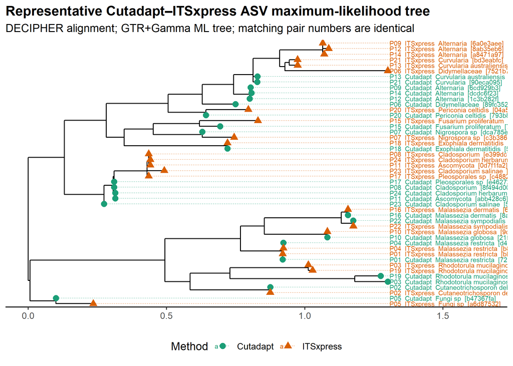

```r
tree_sequences <- c(
  representative_pairs$Cutadapt_Sequence,
  representative_pairs$ITSxpress_Sequence
)
tree_names <- c(
  paste0(representative_pairs$Pair_ID, "|Cut|",
         substr(representative_pairs$Cutadapt_FeatureID, 1, 8)),
  paste0(representative_pairs$Pair_ID, "|ITS|",
         substr(representative_pairs$ITSxpress_FeatureID, 1, 8))
)
names(tree_sequences) <- tree_names

unaligned <- DNAStringSet(tree_sequences)
writeXStringSet(unaligned,
                file.path(results_dir, "05_representative_ASVs_unaligned.fasta"))

alignment <- AlignSeqs(unaligned, processors = 1, verbose = FALSE)
writeXStringSet(alignment,
                file.path(results_dir, "06_representative_ASVs_aligned.fasta"))

phy_dat <- phyDat(as.matrix(alignment), type = "DNA")
distance_ml <- dist.ml(phy_dat)
tree_start <- NJ(distance_ml)
fit_start <- pml(tree_start, data = phy_dat, k = 4)
fit_ml <- suppressWarnings(optim.pml(
  fit_start, model = "GTR", optGamma = TRUE,
  rearrangement = "stochastic",
  control = pml.control(trace = 0)
))

tree_ml <- midpoint(fit_ml$tree)
write.tree(tree_ml, file = file.path(results_dir, "07_representative_ML_tree.nwk"))

tip_metadata <- bind_rows(
  representative_pairs |>
    transmute(
      label = paste0(Pair_ID, "|Cut|", substr(Cutadapt_FeatureID, 1, 8)),
      Pair_ID, Method = "Cutadapt", Taxon_Label,
      Display_Label = paste0(Pair_ID, "  Cutadapt  ", Taxon_Label,
                             "  [", substr(Cutadapt_FeatureID, 1, 8), "]")
    ),
  representative_pairs |>
    transmute(
      label = paste0(Pair_ID, "|ITS|", substr(ITSxpress_FeatureID, 1, 8)),
      Pair_ID, Method = "ITSxpress", Taxon_Label,
      Display_Label = paste0(Pair_ID, "  ITSxpress  ", Taxon_Label,
                             "  [", substr(ITSxpress_FeatureID, 1, 8), "]")
    )
)

tree_plot <- ggtree(tree_ml, linewidth = 0.45) %<+% tip_metadata +
  geom_tippoint(aes(colour = Method, shape = Method), size = 2.5) +
  geom_tiplab(aes(label = Display_Label, colour = Method),
              size = 2.3, linesize = 0.25, align = TRUE) +
  scale_colour_manual(values = method_colors) +
  scale_shape_manual(values = c(Cutadapt = 16, ITSxpress = 17)) +
  xlim_tree(1.65) +
  labs(
    title = "Representative Cutadapt–ITSxpress ASV maximum-likelihood tree",
    subtitle = "DECIPHER alignment; GTR+Gamma ML tree; matching pair numbers are identical",
    colour = "Method", shape = "Method"
  ) +
  theme_tree2(base_size = 10) +
  theme(legend.position = "bottom",
        plot.title = element_text(face = "bold"))

ggsave(file.path(results_dir, "08_representative_ML_tree.png"),
       tree_plot, width = 14, height = 15, dpi = 220,
       bg = "white", limitsize = FALSE)
tree_plot
```

고해상도 계통수 PNG

# 6 6. Tree에서 paired tip이 실제로 가까운가?

각 ITSxpress tip에서 모든 대표 Cutadapt tip까지의 patristic distance를 계산하고, exact-containment 상대 Cutadapt가 몇 번째로 가까운지 확인함. `Rank = 1`이면 해당 Cutadapt ASV가 tree에서도 가장 가까운 Cutadapt tip이라는 뜻임.

```r
tree_distance <- cophenetic(tree_ml)
cut_tips <- tip_metadata$label[tip_metadata$Method == "Cutadapt"]

pair_tree_distance <- representative_pairs |>
  rowwise() |>
  mutate(
    Cut_Tip = paste0(Pair_ID, "|Cut|", substr(Cutadapt_FeatureID, 1, 8)),
    ITS_Tip = paste0(Pair_ID, "|ITS|", substr(ITSxpress_FeatureID, 1, 8)),
    Paired_Patristic_Distance = tree_distance[ITS_Tip, Cut_Tip],
    Rank_Among_Cutadapt = rank(tree_distance[ITS_Tip, cut_tips],
                               ties.method = "min")[match(Cut_Tip, cut_tips)],
    Distance_vs_Median_Cutadapt =
      Paired_Patristic_Distance / median(tree_distance[ITS_Tip, cut_tips])
  ) |>
  ungroup() |>
  select(Pair_ID, Taxon_Label, Paired_Patristic_Distance,
         Rank_Among_Cutadapt, Distance_vs_Median_Cutadapt,
         Cutadapt_Total_Reads, ITSxpress_Total_Reads)

tree_fit_summary <- tibble(
  Representative_Pairs = nrow(representative_pairs),
  Tree_Tips = length(tree_ml$tip.label),
  Alignment_Columns = width(alignment)[1],
  Model = "GTR+Gamma",
  Log_Likelihood = fit_ml$logLik,
  Paired_Cutadapt_is_Nearest_N = sum(pair_tree_distance$Rank_Among_Cutadapt == 1),
  Paired_Cutadapt_is_Top3_N = sum(pair_tree_distance$Rank_Among_Cutadapt <= 3),
  Median_Paired_vs_Other_Distance_Ratio =
    median(pair_tree_distance$Distance_vs_Median_Cutadapt)
)

datatable_basic(tree_fit_summary, 10) |>
  DT::formatRound(c("Log_Likelihood", "Median_Paired_vs_Other_Distance_Ratio"), 4)
```

| Representative_Pairs | Tree_Tips | Alignment_Columns | Model | Log_Likelihood | Paired_Cutadapt_is_Nearest_N | Paired_Cutadapt_is_Top3_N | Median_Paired_vs_Other_Distance_Ratio |
| --- | --- | --- | --- | --- | --- | --- | --- |
| 24 | 48 | 499 | GTR+Gamma | -5623.555488043969 | 13 | 19 | 0.1445275951466309 |

```r
datatable_basic(pair_tree_distance, 24) |>
  DT::formatRound(c("Paired_Patristic_Distance",
                    "Distance_vs_Median_Cutadapt"), 5)
```

| Pair_ID | Taxon_Label | Paired_Patristic_Distance | Rank_Among_Cutadapt | Distance_vs_Median_Cutadapt | Cutadapt_Total_Reads | ITSxpress_Total_Reads |
| --- | --- | --- | --- | --- | --- | --- |
| P01 | Malassezia restricta | 2e-08 | 1 | 1.62172797130864e-08 | 124857 | 128880 |
| P02 | Cutaneotrichosporon debeurmannianum | 2e-08 | 1 | 1.684841817669531e-08 | 50483 | 57752 |
| P03 | Rhodotorula mucilaginosa | 0.8535639529760926 | 3 | 0.6441236002446323 | 24103 | 24420 |
| P04 | Malassezia restricta | 2e-08 | 1 | 1.618535767321385e-08 | 19360 | 19968 |
| P05 | Fungi sp | 0.1353523446323722 | 1 | 0.1305235721404915 | 25439 | 19764 |
| P06 | Didymellaceae | 0.7905708443281305 | 6 | 0.5816124284596939 | 3965 | 16218 |
| P07 | Nigrospora sp | 0.1148563664230223 | 1 | 0.1168746224913134 | 12191 | 14746 |
| P08 | Cladosporium | 0.1323327220605648 | 2 | 0.1355964982001159 | 7822 | 12256 |
| P09 | Alternaria | 0.3843908072650075 | 4 | 0.3419780701282355 | 6245 | 11530 |
| P10 | Malassezia globosa | 2e-08 | 1 | 1.433754090893965e-08 | 9388 | 9921 |

[output cut: 14 more lines]

```r
write_csv(tree_fit_summary, file.path(results_dir, "09_tree_fit_summary.csv"))
write_csv(pair_tree_distance, file.path(results_dir, "10_pair_tree_distances.csv"))
```

# 7 7. 결론

```r
cat(paste0(
  "- ITSxpress fungal ASV ", sum(asv_metrics$Method == "ITSxpress"), "개 중 ",
  n_distinct(pairs$ITSxpress_FeatureID), "개 (",
  percent(n_distinct(pairs$ITSxpress_FeatureID) /
            sum(asv_metrics$Method == "ITSxpress"), accuracy = 0.1),
  ")가 Cutadapt ASV 내부에서 exact match됨.\n",
  "- 이 exact-contained ASV들은 ITSxpress 전체 fungal reads의 ",
  percent(sum(pairs$ITSxpress_Total_Reads) /
            sum(asv_metrics$Total_Reads[asv_metrics$Method == "ITSxpress"]),
          accuracy = 0.1), "를 차지함.\n",
  "- 대표 ", nrow(representative_pairs), "쌍 중 paired Cutadapt tip이 가장 가까운 경우는 ",
  sum(pair_tree_distance$Rank_Among_Cutadapt == 1), "쌍, 상위 3개 안에 드는 경우는 ",
  sum(pair_tree_distance$Rank_Among_Cutadapt <= 3), "쌍임.\n",
  "- tree에서 일부 pair가 바로 이웃하지 않더라도 exact containment가 부정되는 것은 아님. ",
  "full-length Cutadapt 서열과 internal ITSxpress fragment의 gap 구조 및 ITS2 다중서열정렬 불확실성이 tree 거리에 영향을 줌."
))
```

- ITSxpress fungal ASV 1215개 중 740개 (60.9%)가 Cutadapt ASV 내부에서 exact match됨.
- 이 exact-contained ASV들은 ITSxpress 전체 fungal reads의 95.3%를 차지함.
- 대표 24쌍 중 paired Cutadapt tip이 가장 가까운 경우는 13쌍, 상위 3개 안에 드는 경우는 19쌍임.
- tree에서 일부 pair가 바로 이웃하지 않더라도 exact containment가 부정되는 것은 아님. full-length Cutadapt 서열과 internal ITSxpress fragment의 gap 구조 및 ITS2 다중서열정렬 불확실성이 tree 거리에 영향을 줌.